# Tutorial 2

Visualizing Financial Time Series and Checking Normality

Author

Barry Quinn

Published

February 14, 2025

# 1 Introduction

This tutorial helps you develop data exploration skills for financial time series. You will learn to:

1. Use time-series objects in R to organize your data.
2. Create effective visual arguments: time plots, seasonal plots, and subseries plots.
3. Understand distribution properties: Compare your data to the normal distribution (histogram overlays, QQ-plots).
4. Use autocorrelation (ACF) to detect patterns like trend or seasonality.
5. Draw practical conclusions about normality assumptions in finance.

## 1.1 Financial Context

- Financial time series (e.g., stock returns) are often assumed to be normally distributed for simplicity in risk/portfolio models. This assumption underlies key theories like the Capital Asset Pricing Model (CAPM) and Black-Scholes option pricing.
- Empirical evidence, however, shows fat-tailed distributions (more extreme events than normal), volatility clustering (periods of high/low volatility tend to persist), and other departures from normality.
- These deviations from normality can lead to underestimation of market risk, especially during crisis periods.
- Visualization is a first step in diagnosing these issues and understanding the true nature of financial risk.

# 2 Data Setup

We’ll illustrate with a monthly log returns series for Glencore (“GLEN.L”). Feel free to swap in other tickers or use your class data from tsfe.

```r
# Using tidyquant to get monthly log returns from 2018
glen <- tq_get("GLEN.L", from = "2018-01-01") %>%
tq_transmute(select = adjusted,
mutate_fun = monthlyReturn,
type = "log",
col_rename = "log_return")

# Let's convert to a ts object (freq=12 for monthly)
glen_ts <- ts(glen$log_return, frequency = 12, start = c(2018,1))

# Peek at the data
head(glen, 10)
```

```
# A tibble: 10 × 2
   date       log_return
   <date>          <dbl>
 1 2018-01-31     0.0238
 2 2018-02-28    -0.0439
 3 2018-03-29    -0.0880
 4 2018-04-30     0.0109
 5 2018-05-31     0.0591
 6 2018-06-29    -0.0274
 7 2018-07-31    -0.0790
 8 2018-08-31    -0.0647
 9 2018-09-28     0.0812
10 2018-10-31    -0.0395
```

> You’ll see two columns: date and log_return. The glen_ts object is for using forecast-style time-series functions.

# 3 Time-Series Visualisation

## 3.1 Simple Time Plot

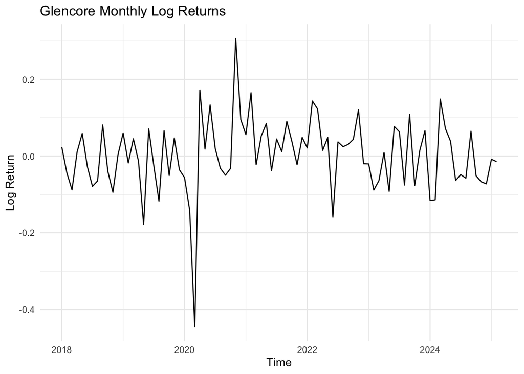

```r
autoplot(glen_ts) +
labs(
title = "Glencore Monthly Log Returns",
x = "Time",
y = "Log Return"
) +
theme_minimal()
```

> **Economic Interpretation:** - Look for clustering of volatility (periods where returns are consistently more volatile) - Major spikes often correspond to significant market events or company news - The overall pattern can indicate regime changes in the company’s risk profile

## 3.2 Seasonal Plot

While monthly equity returns often don’t have a strong seasonal pattern, let’s demonstrate the function:

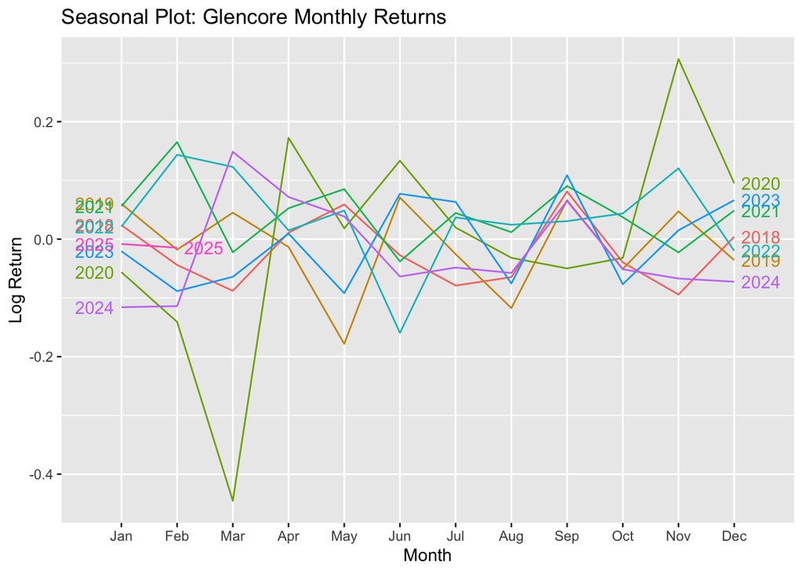

```r
ggseasonplot(glen_ts, year.labels = TRUE, year.labels.left = TRUE) +
labs(
title = "Seasonal Plot: Glencore Monthly Returns",
y = "Log Return",
x = "Month"
)
```

> **Statistical & Economic Context:** - While pure seasonal patterns are rare in equity returns (would violate market efficiency), - Some sectors show seasonal effects (e.g., retail stocks around holidays) - Trading volume often has stronger seasonality than returns - If you see patterns, consider if they’re economically exploitable after transaction costs

## 3.3 Subseries Plot

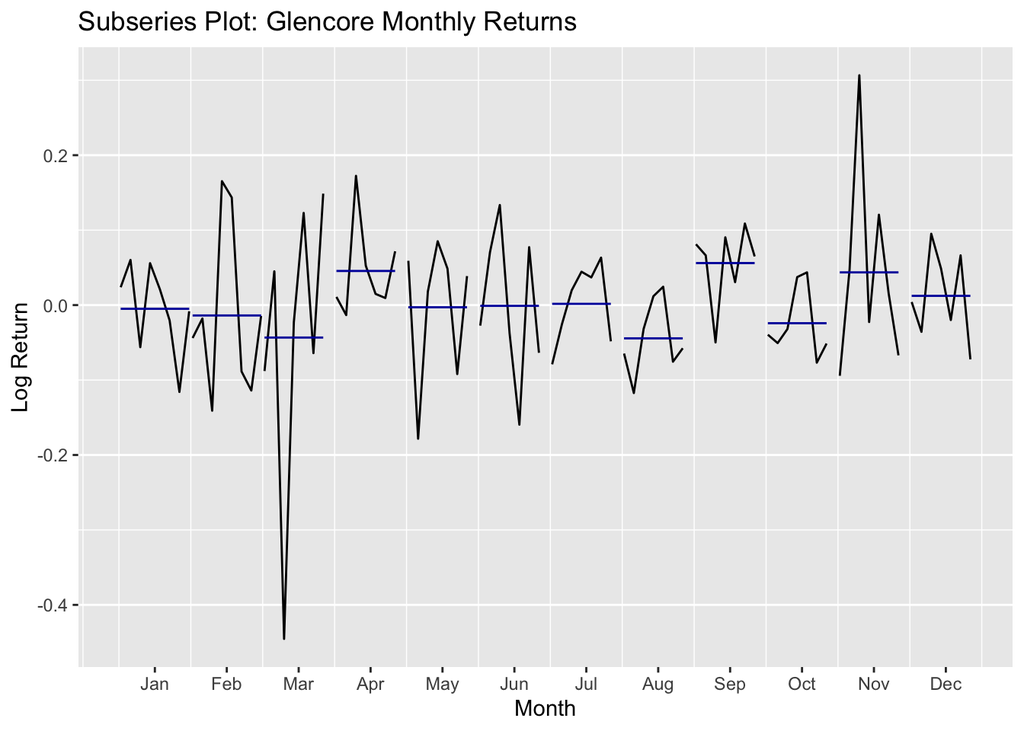

```r
ggsubseriesplot(glen_ts) +
labs(
title = "Subseries Plot: Glencore Monthly Returns",
y = "Log Return"
)
```

> Subseries grouping by month helps highlight any recurring monthly patterns.

# 4 Normality Checks

## 4.1 Histogram with Overlaid Normal

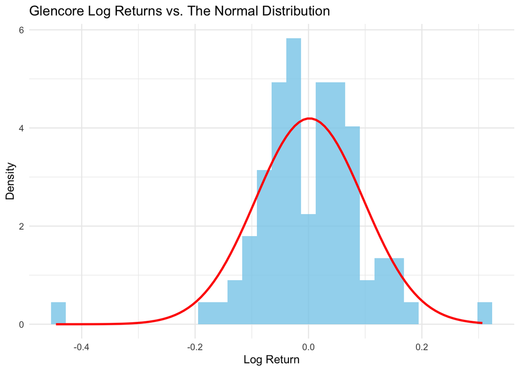

```r
glen %>%
    ggplot(aes(x = log_return)) +
    geom_histogram(aes(y = ..density..), bins = 30, fill="skyblue", alpha = 0.8) +
    stat_function(
        fun = dnorm,
        args = list(mean = mean(glen$log_return),
        sd   = sd(glen$log_return)),
        color = "red",
        size = 1
        ) +
    labs(
    title = "Glencore Log Returns vs. The Normal Distribution",
    x = "Log Return",
    y = "Density"
    ) +
    theme_minimal()
```

> **Statistical Insights:** - Fat tails indicate higher probability of extreme events than predicted by normal distribution - Asymmetry (skewness) might suggest different probabilities of positive vs negative returns - The shape often reflects the market regime (crisis vs stable periods show different distributions)

## 4.2 QQ-Plot

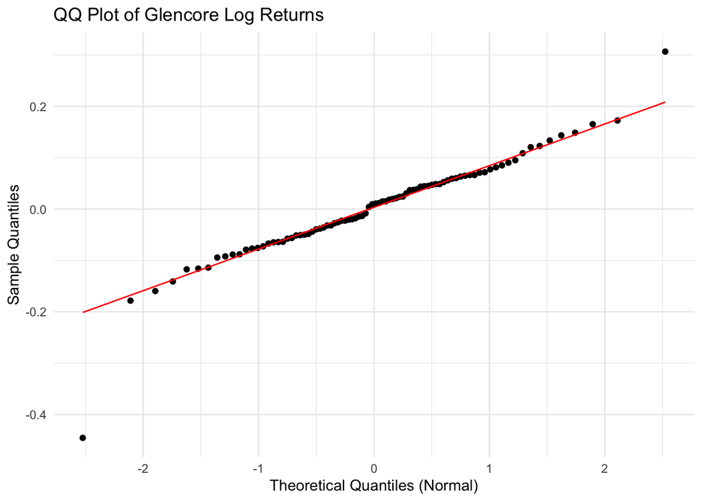

```r
glen %>% ggplot(aes(sample = log_return)) +
    stat_qq(distribution = qnorm) +
    stat_qq_line(distribution = qnorm, color="red") +
    labs( title = "QQ Plot of Glencore Log Returns",
           x = "Theoretical Quantiles (Normal)",
           y = "Sample Quantiles" ) +
    theme_minimal()
```

**Interpretation:**

- Points above the line in the right tail indicate more extreme positive returns than expected under normality
- Points below the line in the left tail indicate more extreme negative returns
- The pattern often reveals asymmetric risk (e.g., crashes being more severe than booms)
- This has important implications for risk management and option pricing

## 4.3 Shapiro-Wilk Test

```r
shapiro.test(glen$log_return)
```

```
    Shapiro-Wilk normality test

data:  glen$log_return
W = 0.92853, p-value = 0.0001418
```

- Null hypothesis: The data are normally distributed.
- If p-value < 0.05, we usually reject normality.
- Caution: Large sample sizes can make tiny deviations appear significant.

# 5 Autocorrelation & Seasonal Patterns

## 5.1 Autocorrelation Function (ACF)

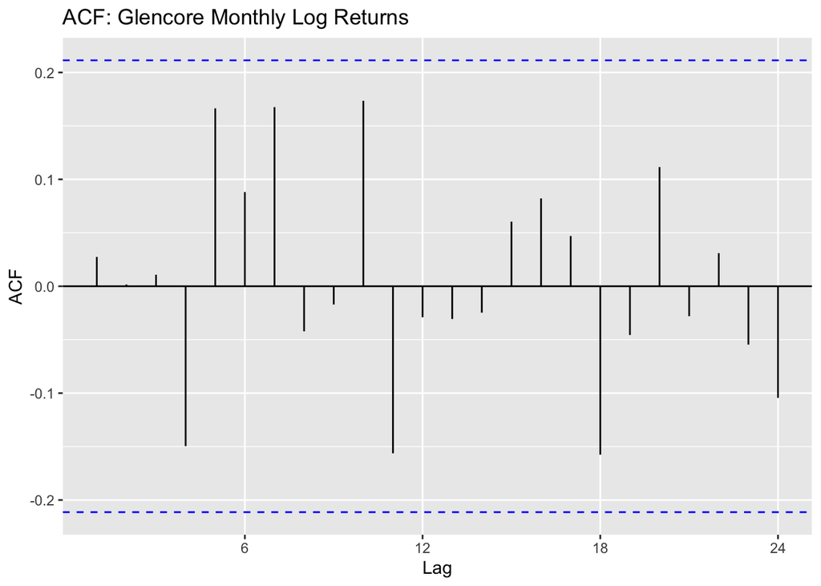

```r
ggAcf(glen_ts) + labs(title = "ACF: Glencore Monthly Log Returns")
```

**ACF Interpretation:** - Significant autocorrelation challenges the Efficient Market Hypothesis - Positive autocorrelation suggests momentum effects (trending) - Negative autocorrelation suggests mean reversion - The decay pattern of ACF can inform trading strategy horizons - Remember that statistical significance doesn’t always equal economic significance (after costs)

## 5.2 Lag Plot

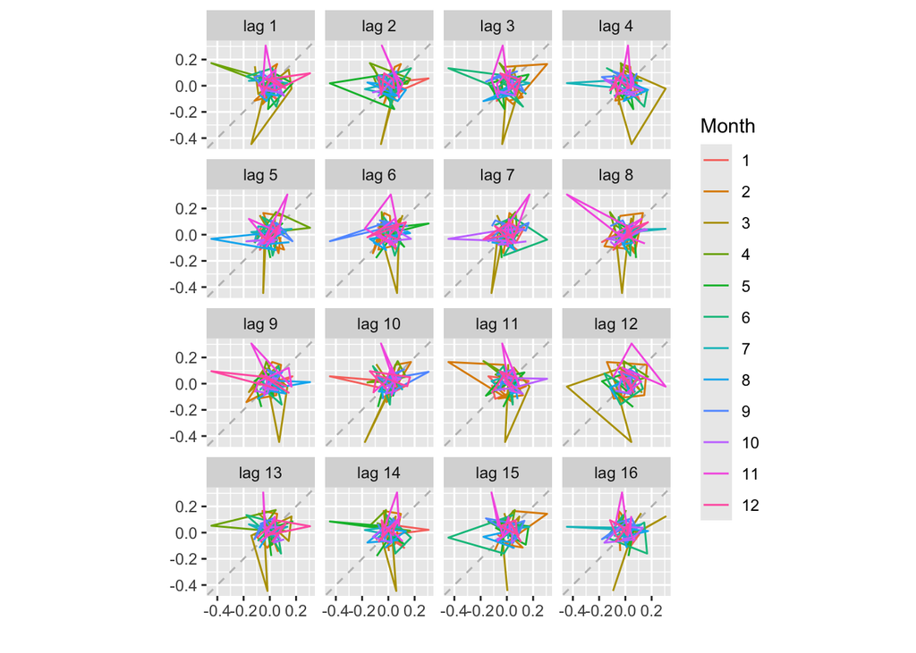

```r
gglagplot(glen_ts)
```

# 6 Exercises

Change the Ticker:

Choose a different stock (e.g. “AMZN”, “BARC.L” for Barclays, etc.) and replicate steps 3–5.

2. Discuss Normality:
- Does the histogram or QQ-plot indicate fat tails?
- Why might normality be a poor assumption for daily or monthly returns?
3. Autocorrelation:
- Are you seeing any significant correlation at lag=1 or lag=2?
- If so, what might that imply about “efficient market” assumptions?
4. Seasonality:
- If you do see a monthly pattern, can you guess economic reasons behind it?

# 7 Conclusion

**Key Takeaways:**

- Visual arguments are vital: time plots, QQ-plots, and ACF often reveal critical patterns that summary statistics obscure
- Normality assumptions in finance are convenient but dangerous - risk models need to account for fat tails
- Market efficiency doesn’t require perfect randomness - small predictabilities may exist but be hard to profit from
- The interaction between statistical patterns and economic reasoning is crucial for financial analysis
- These tools form the foundation for more advanced models in risk management and trading